# A Beginner’s Guide to R

Xi Li

6/22/2021

Hello everyone! Welcome to your R journey. Today we are exploring some very simple operations using the R software.

## Assigning values

There are two ways for assigning values, i.e., using “=” or “<-”.

```r
x = 100
y <- x + 10
z <- 'Marketing'
print(c(x, y, z))
```

```
## [1] "100"       "110"       "Marketing"
```

## Printing values

In the above code, we use the print function to print an output. You can either print a single value or multiple values.

```r
print('HKU')
```

```
## [1] "HKU"
```

```r
print(c('a','b','c'))
```

```
## [1] "a" "b" "c"
```

## Simple Algebra

You can also try some simple algebraic operations on R.

```r
x <- 100
y <- 50.5
z1 <- x + y
z2 <- x - y
z3 <- x*y
z4 <- x/y
z5 <- y^2
z6 <- sqrt(x)
print(c(z1,z2,z3,z4,z5,z6))
```

```
## [1]  150.500000   49.500000 5050.000000    1.980198 2550.250000   10.000000
```

## Logic operators

A logic variable is either “TRUE” or “FALSE”.

```r
x <- TRUE
y <- FALSE
a <- 100
b <- (a == 99)
c <- (a >= 99)
d <- (a != 99)
print(c(b, c, d))
```

```
## [1] FALSE  TRUE  TRUE
```

## String operations

String concatenation allows you to merge two concatenate two strings. R provides you with two functions, namely “paste” and “paste0”.

```r
x <- "Welcome"
y <- "to"
z <- "Marketing"
result <- paste(x, y, z)
result0 <- paste0(x, y, z)
print(c(result, result0))
```

```
## [1] "Welcome to Marketing" "WelcometoMarketing"
```

Sometimes we want to convert a number to a string. You can do this:

```r
x <- 100
y <- 200
sx <- toString(x)
sy <- toString(y)
print(c(x, y, paste0(sx,sy)))
```

```
## [1] "100"    "200"    "100200"
```

Counting the length of a string:

```r
str = "Marketing and Big Data"
print(nchar(str))
```

```
## [1] 22
```

Splitting the string based on SPACE:

```r
str = "Marketing and Big Data"
y = strsplit(str,split=' ')
print(y)
```

```
## [[1]]
## [1] "Marketing" "and"       "Big"       "Data"
```

Obtaining a substring.

```r
str = "Marketing and Big Data"
z = substr(str, 2,5)
#substring from the 2nd to the 5th character
print(z)
```

```
## [1] "arke"
```

## List

A list is an ordered sequence of objects:

```r
vec <- c(1,3,5)
char_vec <- c("Spring", "Summer", "Autumn", "Winter")
logic_vec <- c(TRUE, FALSE, TRUE, FALSE)
print(vec)
```

```
## [1] 1 3 5
```

```r
print(char_vec)
```

```
## [1] "Spring" "Summer" "Autumn" "Winter"
```

```r
print(logic_vec)
```

```
## [1]  TRUE FALSE  TRUE FALSE
```

You may also put different types of variables in a list:

```r
list <- c(100, 'HKU', TRUE, 10 + 15)
print(list)
```

```
## [1] "100"  "HKU"  "TRUE" "25"
```

```r
summary(cars)
```

```
##      speed           dist
##  Min.   : 4.0   Min.   :  2.00
##  1st Qu.:12.0   1st Qu.: 26.00
##  Median :15.0   Median : 36.00
##  Mean   :15.4   Mean   : 42.98
##  3rd Qu.:19.0   3rd Qu.: 56.00
##  Max.   :25.0   Max.   :120.00
```

## Simple Plots

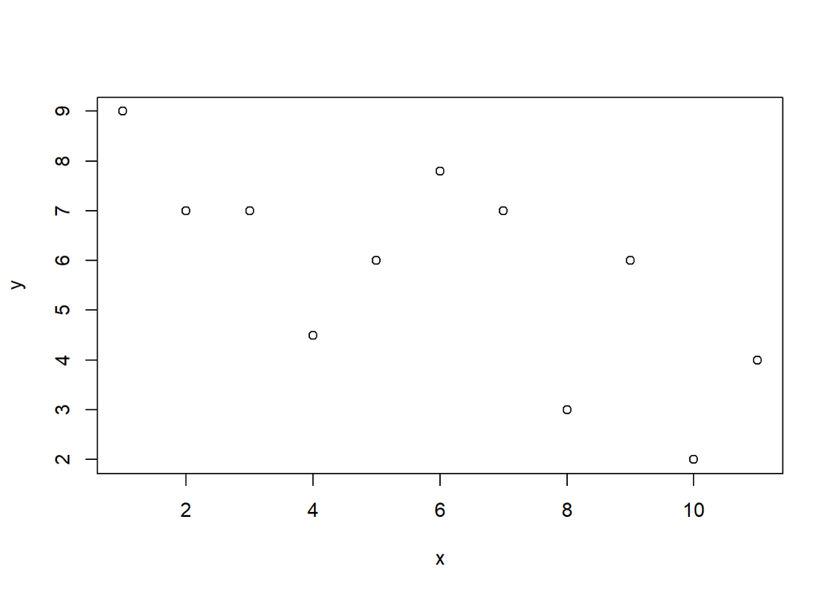

```r
x <- c(1, 2, 3, 4, 5, 6, 7, 8, 9, 10, 11)
y <- c(9, 7, 7, 4.5, 6, 7.8, 7, 3, 6, 2, 4)
plot(x, y)
```

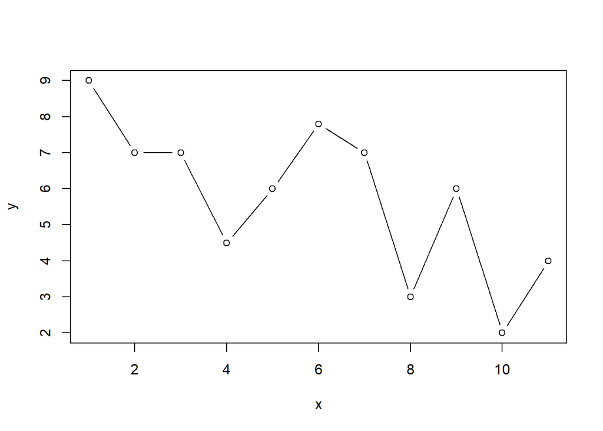

```r
plot(x, y, type = "b")
```

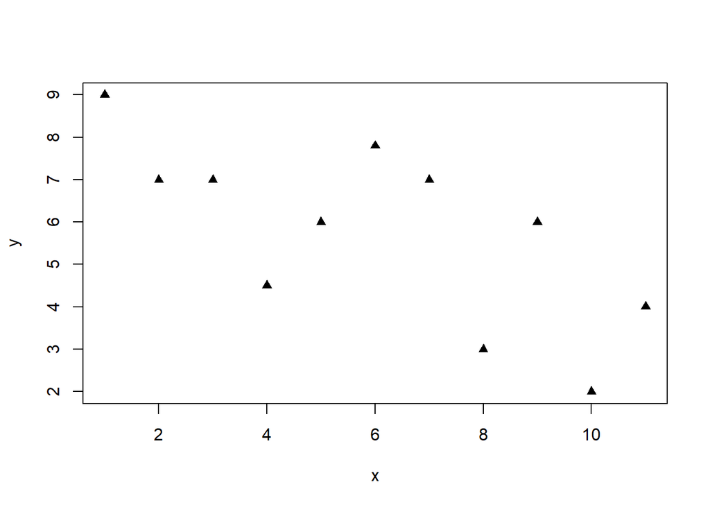

```r
plot(x, y, pch = 17)
```

The “pch” instruction defines the appearance of your points, while the “lty” instruction defines the appearance of your line. For details, please refer to [pch notes](http://www.sthda.com/english/wiki/r-plot-pch-symbols-the-different-point-shapes-available-in-r) and [lty notes](http://www.sthda.com/english/wiki/line-types-in-r-lty)

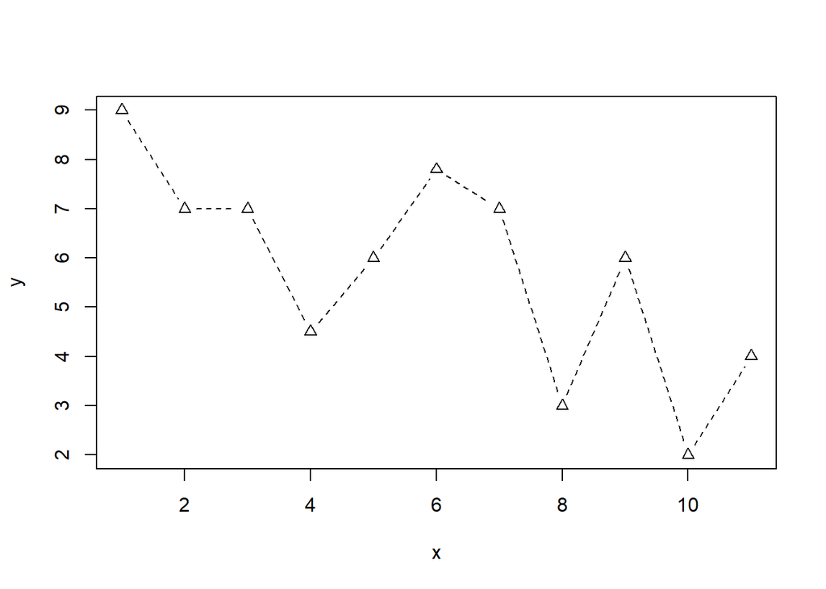

```r
x <- c(1, 2, 3, 4, 5, 6, 7, 8, 9, 10, 11)
y <- c(9, 7, 7, 4.5, 6, 7.8, 7, 3, 6, 2, 4)
plot(x, y, pch = 2, lty = 2, type = "b")
```

You can find more details of plotting [here](https://www.rdocumentation.org/packages/graphics/versions/3.6.2/topics/plot).

## Data Plots

R also provides us with some useful packages for data plotting. The most useful one is called “ggplot”. You need to install it first.

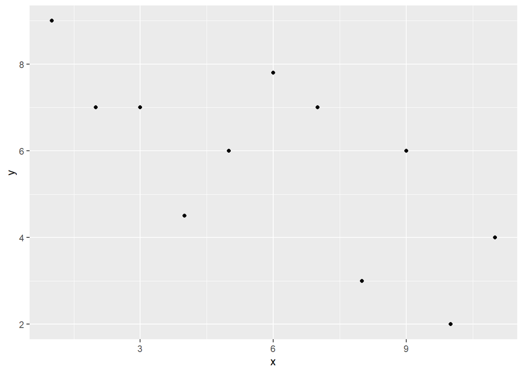

```r
# install the package
 install.packages("ggplot2", repos = "http://cran.us.r-project.org")
# use the package
library(ggplot2)
# create data
x <- c(1, 2, 3, 4, 5, 6, 7, 8, 9, 10, 11)
y <- c(9, 7, 7, 4.5, 6, 7.8, 7, 3, 6, 2, 4)
data <- data.frame(x, y)
# Plot
ggplot(data, aes(x, y)) + geom_point()
```

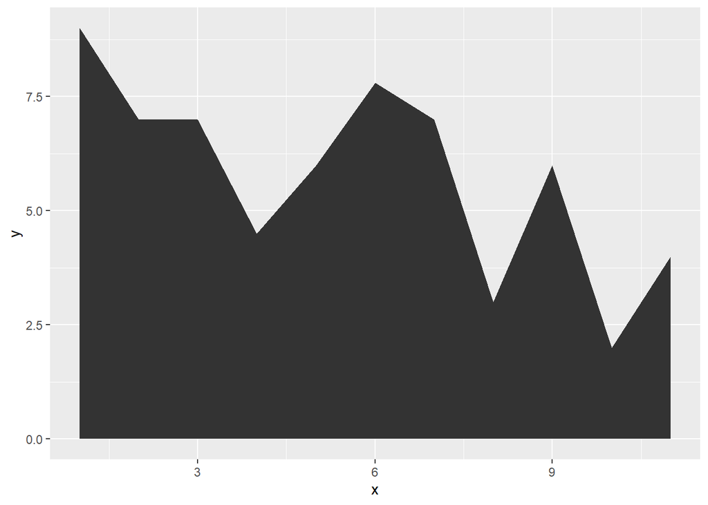

```r
ggplot(data, aes(x, y)) + geom_area()
```

Next let us add colors to the plots.

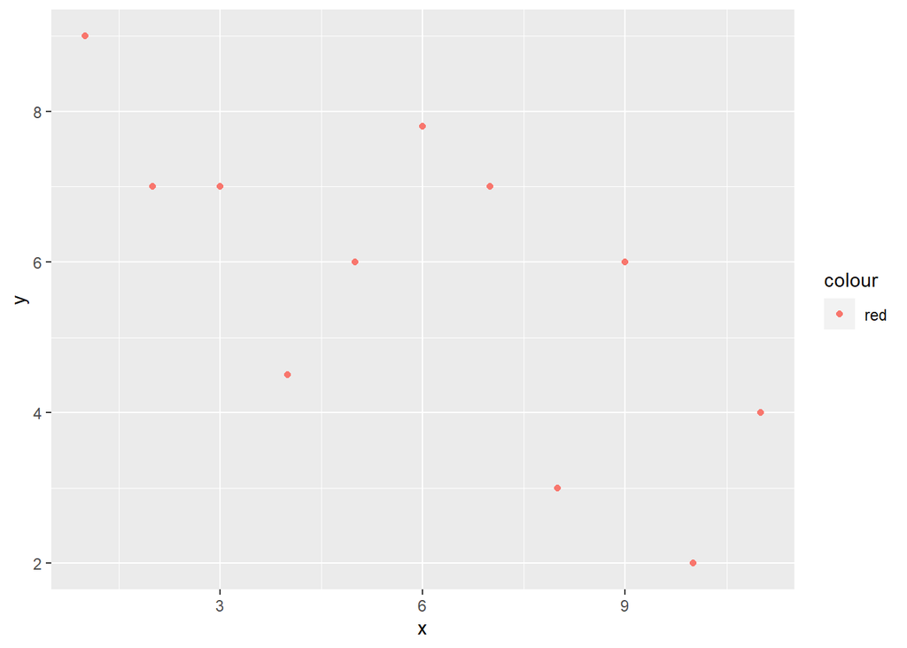

```r
# Here, for each individual, we have three values, its X, its Y, and its gender (e.g., 1 for male and 0 for female).
x <- c(1, 2, 3, 4, 5, 6, 7, 8, 9, 10, 11)
y <- c(9, 7, 7, 4.5, 6, 7.8, 7, 3, 6, 2, 4)
gender <- c(0, 0, 0, 0, 0, 1, 1, 1, 1, 1, 1)
data <- data.frame(x, y, gender)
# We plot the points in red
ggplot(data, aes(x, y, color = 'red')) + geom_point()
```

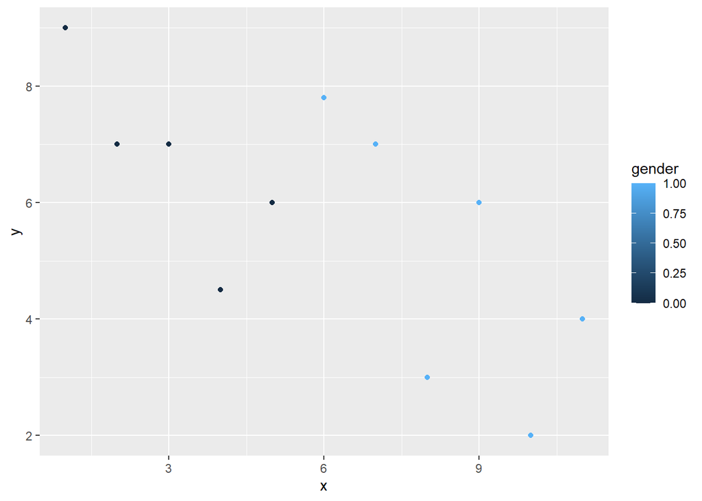

```r
# We plot the points based on gender (one color for one gender)
ggplot(data, aes(x, y, color = gender)) + geom_point()
```

## Data Frame

A data frame is a list of variables of the same number of rows with unique row names, given class “data.frame”.

```r
  employees <- data.frame(
    name = c('Alice', 'Bob', 'Carol', 'Denis'),
    salary = c(20000,19000,23000,22000),
    job = c('IT', 'Sales', 'Finance', 'IT' ))
```

You may have missing values in your data frame. In this case you can enter “NA” to represent the missing value.

```r
employees <- data.frame(
  name = c('Alice', 'Bob', 'Carol','Denis'),
  salary = c(20000,NA,23000,22000),
  job = c('IT', 'Sales', NA, 'IT'))
```

You can use the dollar sign“$” to select a specific variable:

```r
print(employees)
```

```
##    name salary   job
## 1 Alice  20000    IT
## 2   Bob     NA Sales
## 3 Carol  23000  <NA>
## 4 Denis  22000    IT
```

```r
print(summary(employees))
```

```
##      name               salary          job
##  Length:4           Min.   :20000   Length:4
##  Class :character   1st Qu.:21000   Class :character
##  Mode  :character   Median :22000   Mode  :character
##                     Mean   :21667
##                     3rd Qu.:22500
##                     Max.   :23000
##                     NA's   :1
```

```r
print(employees$name)
```

```
## [1] "Alice" "Bob"   "Carol" "Denis"
```

## Simple Satistics

```r
vector <- c(0, 8, 4, 6, 7, 9, 5)
print(mean(vector))
```

```
## [1] 5.571429
```

```r
print(median(vector))
```

```
## [1] 6
```

```r
print(var(vector))     #variance
```

```
## [1] 8.952381
```

```r
print(sd(vector))      #standard deviation
```

```
## [1] 2.992053
```

```r
print(max(vector))     #maximum
```

```
## [1] 9
```

```r
print(min(vector))     #mimimum
```

```
## [1] 0
```

```r
print(sort(vector))    #sort the data in increasing order
```

```
## [1] 0 4 5 6 7 8 9
```

## IF ELSE

```r
x <- 0
if (x < 0) {
  print("Negative number")
} else if (x > 0) {
  print("Positive number")
} else
  print("Zero")
```

```
## [1] "Zero"
```

## WHILE LOOP

```r
count = 0
while (count <= 5)
{
  count = count + 1
  print(count)
}
```

```
## [1] 1
## [1] 2
## [1] 3
## [1] 4
## [1] 5
## [1] 6
```

## FOR LOOP

```r
vector = c(1, 3, 5, 7)
print(vector)
```

```
## [1] 1 3 5 7
```

```r
for (item in vector)
  print(item)
```

```
## [1] 1
## [1] 3
## [1] 5
## [1] 7
```

## FOR LOOP with skip logic

```r
for (year in 2000: 2020)
  print (year)
```

```
## [1] 2000
## [1] 2001
## [1] 2002
## [1] 2003
## [1] 2004
## [1] 2005
## [1] 2006
## [1] 2007
## [1] 2008
## [1] 2009
## [1] 2010
## [1] 2011
## [1] 2012
## [1] 2013
## [1] 2014
## [1] 2015
## [1] 2016
## [1] 2017
## [1] 2018
## [1] 2019
## [1] 2020
```

```r
for (year in 2000: 2020)
{
  if(year == 2008)
    next        #skip to the next iteration
  print (year)
}
```

```
## [1] 2000
## [1] 2001
## [1] 2002
## [1] 2003
## [1] 2004
## [1] 2005
## [1] 2006
## [1] 2007
## [1] 2009
## [1] 2010
## [1] 2011
## [1] 2012
## [1] 2013
## [1] 2014
## [1] 2015
## [1] 2016
## [1] 2017
## [1] 2018
## [1] 2019
## [1] 2020
```

## Functions

```r
f1 <- function(a) {
  print(a + 1)
}

f1(0.5)
```

```
## [1] 1.5
```

```r
f1(2)
```

```
## [1] 3
```

Another example:

```r
f2 <- function(a) {
  return(a+2)
}

print(f2(0.5))
```

```
## [1] 2.5
```

```r
print(f2(2))
```

```
## [1] 4
```

Yet another example:

```r
f3 <- function(a) {
  a <- toString(a)
  a <- paste(a, "data")
  return (a)
}

print(f3(100))
```

```
## [1] "100 data"
```

```r
print(f3("big"))
```

```
## [1] "big data"
```

More examples…

```r
f4 <- function(a) {
  r1 <- a + 1
  r2 <- a + 2
  mylist <- list("r1" = r1, "r2" = r2)
  return(mylist)
}

mylist <- f4(15)
print(mylist$r1)
```

```
## [1] 16
```

```r
print(mylist$r2)
```

```
## [1] 17
```

Generating random variables from uniform distribution:

```r
a = runif(1)   #generate a random number between 0 and 1
print(a)
```

```
## [1] 0.8493704
```

```r
vec = runif(5) #generate a list of 5 random numbers
print(vec)
```

```
## [1] 0.5981136 0.4764372 0.1625948 0.1456570 0.8633295
```

```r
vec = runif(3, min=0, max=100)
#generate 3 random numbers between 0 and 100
print(vec)
```

```
## [1] 65.45418 25.33918 34.43393
```

Generating random variables from normal distribution:

```r
x = rnorm(1)
#generate a random number using the standard normal distribution
print (x)
```

```
## [1] 0.7875174
```

```r
y = rnorm(4, mean=50, sd=10)
#generate 4 random numbers following the specified normal distribition
print (y)
```

```
## [1] 45.00705 36.68992 73.94876 57.05236
```

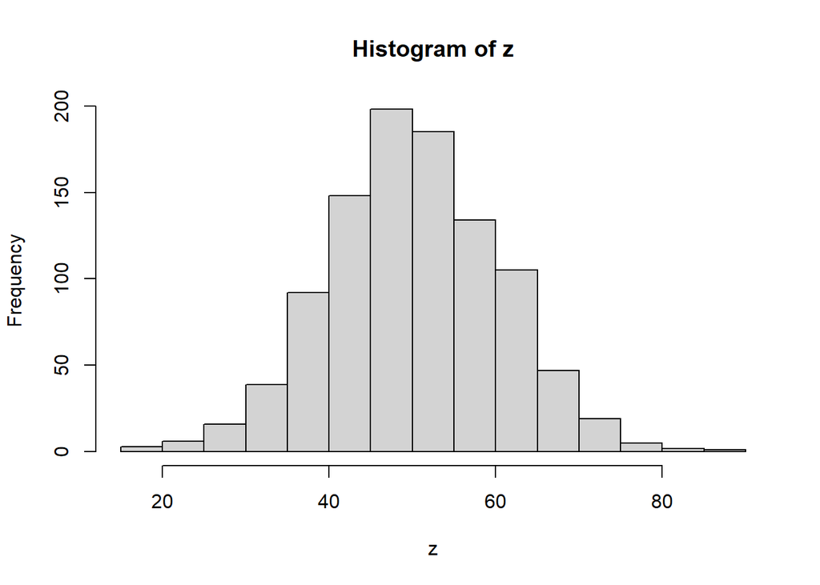

```r
z <- rnorm(1000, mean=50, sd=10)
hist(z)
```

```r
#generate the histogram of z
```

Plotting histograms using ggplot2:

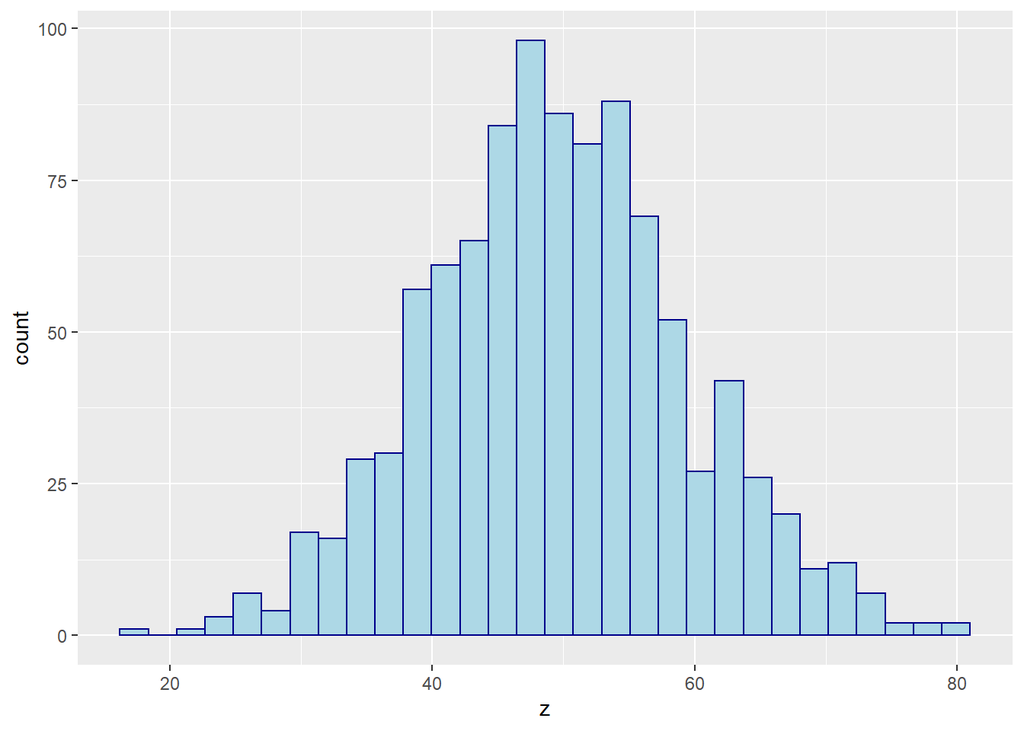

```r
library(ggplot2)
z <- rnorm(1000, mean=50, sd=10)
data <- data.frame(z)

figure <- ggplot(data, aes(z))+
  geom_histogram(color="darkblue", fill="lightblue")
figure
```

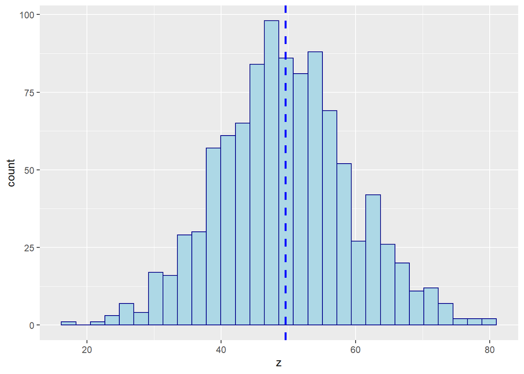

```r
figure + geom_vline(aes(xintercept=mean(z)),
                       color="blue", linetype="dashed", size=1)
```

## Getting and setting your working directories:

```r
getwd()
```

```
## [1] "C:/Users/Li Xi/Dropbox/Marketing Classes/Algorithm"
```

```r
#get working directory

setwd('C:/Users/Li Xi/Dropbox/Marketing Classes/Algorithm')
#set working directory
getwd()
```

```
## [1] "C:/Users/Li Xi/Dropbox/Marketing Classes/Algorithm"
```

## Writing to text files:

```r
file1<-file("output.txt")
writeLines(c("Big","Data"), file1)
close(file1)

file2<-file("C:/Users/Li Xi/Dropbox/Marketing Classes/output.txt")
writeLines(c("Big","Data"), file2)
close(file2)
```

In the above output, Here, “C:/Users/Li Xi/Dropbox/Marketing Classes/output.txt” is the path to your txt file. You can think of it as the address of your txt file.

You can also write: “C:\\Users\\Li Xi\\Dropbox\\Marketing Classes\\output.txt” to refer to your txt file.

However, you cannot write “C:\Users\Li Xi\Dropbox\Marketing Classes\output.txt”.

Another way to write the file:

```r
sink("output.txt")
cat("Big")
```

```
## Big
```

```r
cat("\n")      #set up a new line
```

```r
cat("Data")
```

```
## Data
```

```r
sink()
```

Write a dataframe:

```r
employees <- data.frame(
  name = c('Alice', 'Bob', 'Carol','Denis'),
  salary = c(20000,NA,23000,22000),
  job = c('IT', 'Sales', NA, 'IT'))

setwd('C:/Users/Li Xi/Dropbox/Marketing Classes/Algorithm')
write.table(employees, file = "output.txt", sep = "\t", row.names = FALSE)
```

## Reading a CSV (Excel) file

R allows you to read data from various files. If you want to read a spreadsheet, you are recommended to save the file as a csv file (Comma-Separated Values), and open it with the following codes:

```r
mydata <- read.csv("C:/Users/Li Xi/Dropbox/r-exercise.csv",
                   fileEncoding = "UTF-8-BOM")
```

And you can also get the file from a URL address:

```r
mydata <- read.csv("https://ximarketing.github.io/class/teachingfiles/r-exercise.csv", fileEncoding = "UTF-8-BOM")
```

```r
head(mydata)
```

|  | Rating | Expertise | Votes | Purpose |
| --- | --- | --- | --- | --- |
| 1 | 4 | 6 | 0 | couple |
| 2 | 5 | 5 | 0 | friend |
| 3 | 5 | 5 | 0 | family |
| 4 | 4 | 4 | 0 | family |
| 5 | 4 | 4 | 0 | business |
| 6 | 5 | 5 | 0 | family |

## Summary Statistics

Next we show the summary statistics of the data:

```r
summary(mydata)
```

```
##      Rating        Expertise         Votes           Purpose
##  Min.   :1.000   Min.   :0.000   Min.   : 0.0000   Length:180635
##  1st Qu.:4.000   1st Qu.:1.000   1st Qu.: 0.0000   Class :character
##  Median :5.000   Median :3.000   Median : 0.0000   Mode  :character
##  Mean   :4.286   Mean   :2.892   Mean   : 0.8217
##  3rd Qu.:5.000   3rd Qu.:5.000   3rd Qu.: 1.0000
##  Max.   :5.000   Max.   :6.000   Max.   :75.0000
```

## Number of Rows and Columns

```r
nrow(mydata)
```

```
## [1] 180635
```

```r
ncol(mydata)
```

```
## [1] 4
```

## Plotting histograms, again

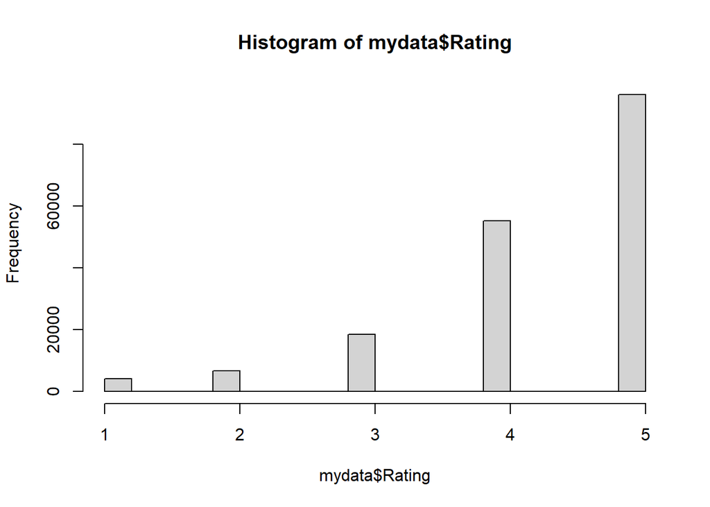

```r
hist(mydata$Rating)
```

## Choosing a subset of your data

Suppose that we only want to use reviews with rating <= 4.

```r
subdata <- subset(mydata, Rating <= 4)
head(subdata)
```

|  | Rating | Expertise | Votes | Purpose |
| --- | --- | --- | --- | --- |
| 1 | 4 | 6 | 0 | couple |
| 4 | 4 | 4 | 0 | family |
| 5 | 4 | 4 | 0 | business |
| 7 | 4 | 3 | 0 | family |
| 11 | 4 | 4 | 0 | couple |
| 12 | 4 | 5 | 0 | couple |

## Linear Regression (Important!!!)

Suppose that you want to do the following regression analysis on the dataset mydata:

Rating= a + b1 Experience

```r
result <- lm(Rating ~ Expertise, data = mydata)
summary(result)
```

```
##
## Call:
## lm(formula = Rating ~ Expertise, data = mydata)
##
## Residuals:
##     Min      1Q  Median      3Q     Max
## -3.3326 -0.3003  0.6674  0.7158  0.7642
##
## Coefficients:
##              Estimate Std. Error t value Pr(>|t|)
## (Intercept)  4.332610   0.003872 1118.98   <2e-16 ***
## Expertise   -0.016138   0.001091  -14.79   <2e-16 ***
## ---
## Signif. codes:  0 '***' 0.001 '**' 0.01 '*' 0.05 '.' 0.1 ' ' 1
##
## Residual standard error: 0.9531 on 180633 degrees of freedom
## Multiple R-squared:  0.001209,   Adjusted R-squared:  0.001203
## F-statistic: 218.6 on 1 and 180633 DF,  p-value: < 2.2e-16
```

In the above regression formulation, “lm” stands for “linear models”.

This means you get the following result:

Rating=4.332−0.016 Experience

We can make predictions based on the regression out. For example, suppose we have another review with expertise 4, then you can do the followings:

```r
prediction <- predict(result, data.frame(Expertise = 4))
print(prediction)
```

```
##       1
## 4.26806
```

Likewise, we can also run multiple regression:

```r
result <- lm(Votes ~ Expertise + Rating, data = mydata)
summary(result)
```

```
##
## Call:
## lm(formula = Votes ~ Expertise + Rating, data = mydata)
##
## Residuals:
##    Min     1Q Median     3Q    Max
## -1.421 -0.860 -0.686  0.301 74.301
##
## Coefficients:
##              Estimate Std. Error t value Pr(>|t|)
## (Intercept)  1.573719   0.019761  79.637   <2e-16 ***
## Expertise    0.004350   0.001979   2.198    0.028 *
## Rating      -0.178399   0.004264 -41.840   <2e-16 ***
## ---
## Signif. codes:  0 '***' 0.001 '**' 0.01 '*' 0.05 '.' 0.1 ' ' 1
##
## Residual standard error: 1.727 on 180632 degrees of freedom
## Multiple R-squared:  0.009671,   Adjusted R-squared:  0.00966
## F-statistic:   882 on 2 and 180632 DF,  p-value: < 2.2e-16
```

Similarly, we can also make predictions based on the regression result:

```r
prediction <- predict(result, data.frame(Expertise = 4, Rating = 2))
print(prediction)
```

```
##       1
## 1.23432
```

## Linear Regression with Fixed Effects

Moreover, we can also run linear regression with fixed effects: Here, we take purpose as a fixed effect which takes the following values: business, couple, family, friend, solo, and unknown.

```r
result <- lm(Votes ~ Expertise + Rating + factor(Purpose), data = mydata)
summary(result)
```

```
##
## Call:
## lm(formula = Votes ~ Expertise + Rating + factor(Purpose), data = mydata)
##
## Residuals:
##    Min     1Q Median     3Q    Max
## -2.382 -0.761 -0.593  0.312 73.350
##
## Coefficients:
##                         Estimate Std. Error t value Pr(>|t|)
## (Intercept)             1.405531   0.020426  68.812  < 2e-16 ***
## Expertise               0.004507   0.001960   2.299   0.0215 *
## Rating                 -0.180778   0.004238 -42.660  < 2e-16 ***
## factor(Purpose)couple   0.176869   0.011199  15.794  < 2e-16 ***
## factor(Purpose)family   0.091479   0.012095   7.564 3.94e-14 ***
## factor(Purpose)friend   0.065447   0.016380   3.996 6.46e-05 ***
## factor(Purpose)solo     0.081461   0.018771   4.340 1.43e-05 ***
## factor(Purpose)Unknown  1.130019   0.016878  66.954  < 2e-16 ***
## ---
## Signif. codes:  0 '***' 0.001 '**' 0.01 '*' 0.05 '.' 0.1 ' ' 1
##
## Residual standard error: 1.704 on 180627 degrees of freedom
## Multiple R-squared:  0.03619,    Adjusted R-squared:  0.03615
## F-statistic: 968.9 on 7 and 180627 DF,  p-value: < 2.2e-16
```

And making predictions accordingly…

```r
prediction <- predict(result, data.frame(Expertise = 4, Rating = 2, Purpose = "family"))
print(prediction)
```

```
##        1
## 1.153482
```

## The Stargazer Package

The stargazer package is very useful for organizing the regression output in a table. You need to install it first.

```r
# install the package
install.packages("stargazer", repos = "http://cran.us.r-project.org")
# use the package
library(stargazer)
stargazer(result, title = "regression output", align = TRUE, out = "regression.html", type = "html")
```

[output not shown]

You can also generate an output based on several regressions:

```r
result0 <- lm(Votes ~ Expertise, data = mydata)
result1 <- lm(Votes ~ Expertise + Rating, data = mydata)
result2 <- lm(Votes ~ Expertise + Rating + factor(Purpose), data = mydata)
stargazer(result0, result1, result2, title = "regression output", align = TRUE, out = "regression.html", type = "html")
```

[output not shown]

We can easily generate the summary statistics of our dataset:

```r
stargazer(mydata, title = "Summary Statistics", align = TRUE, out = "summary.html", type = "html")
```

[output not shown]

## Another Example of Linear Regression

In this regression, our dataset comes from Los Angeles Neighborhoods Data. The data source is [here](http://wiki.stat.ucla.edu/socr/index.php/SOCR_Data_LA_Neighborhoods_Data#Data_Source).

It covers some basic information of several neighborhoods in Los Angeles (e.g., income, age, ethnic group, …)

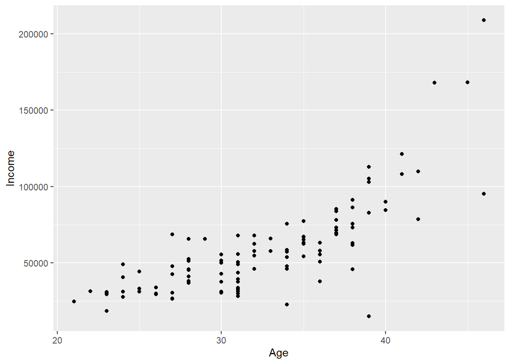

```r
library(ggplot2)
file = "https://ximarketing.github.io/class/teachingfiles/r-exercise.txt"
mydata <- read.table(file, header = TRUE)
ggplot(mydata,aes(y=Income,x=Age))+geom_point()
```

Plotting the regression line:

```r
result <- lm(Income ~ Age, data = mydata)
summary(result)
```

```
##
## Call:
## lm(formula = Income ~ Age, data = mydata)
##
## Residuals:
##    Min     1Q Median     3Q    Max
## -70208  -9605  -1762   9509  94968
##
## Coefficients:
##             Estimate Std. Error t value Pr(>|t|)
## (Intercept)   -74588      10950  -6.812 5.68e-10 ***
## Age             4097        332  12.341  < 2e-16 ***
## ---
## Signif. codes:  0 '***' 0.001 '**' 0.01 '*' 0.05 '.' 0.1 ' ' 1
##
## Residual standard error: 19880 on 108 degrees of freedom
## Multiple R-squared:  0.5851, Adjusted R-squared:  0.5813
## F-statistic: 152.3 on 1 and 108 DF,  p-value: < 2.2e-16
```

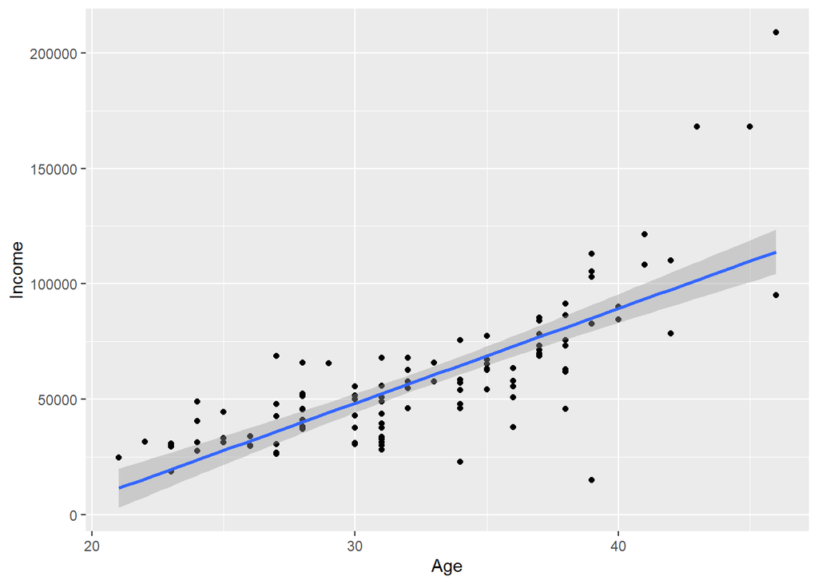

```r
ggplot(mydata,aes(y=Income,x=Age))+geom_point()+geom_smooth(method="lm")
```

## T-Test

It is very convenient to run a t-test in R:

```r
x = c(1, 3, 3, 5, 3, 2, 4, 3, 5, 7)
y = c(2, 6, 3, 4, 5, 2, 5, 8, 1, 6)
t.test(x, y)
```

```
##
##  Welch Two Sample t-test
##
## data:  x and y
## t = -0.68034, df = 16.975, p-value = 0.5055
## alternative hypothesis: true difference in means is not equal to 0
## 95 percent confidence interval:
##  -2.46089  1.26089
## sample estimates:
## mean of x mean of y
##       3.6       4.2
```

Visualizing t-tests:

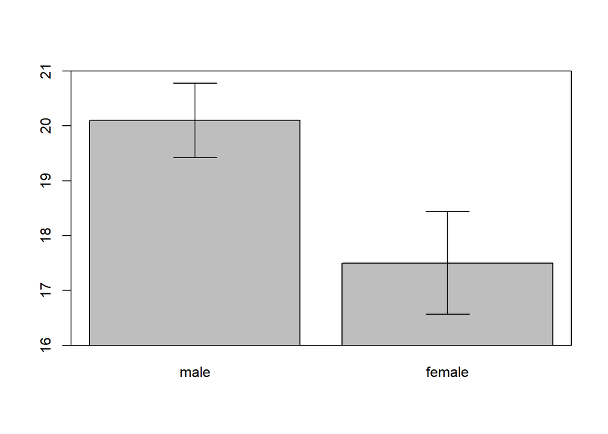

```r
male <- c(18,22,21,17,20,17,23,20,22,21)
female <- c(16,20,14,21,20,18,13,15,17,21)
data        = c(mean(male), mean(female))
names(data) = c("male", "female")
se       = c(sd(male)/sqrt(length(male)),
          sd(female)/sqrt(length(female)))
windows()
bp = barplot(data, ylim=c(16, 21), xpd=FALSE)
box()
arrows(x0=bp, y0=data-se, y1=data+se, code=3, angle=90)
```